# Spotify Library Analysis

This dataset consist of all the tracks that currently exists on my Spotify Library. In other words, all of the tracks (or group of them) that I’ve *liked*. Told Spotify that I’m into that song. Each row consist of a single track i.e. an event registering. The goal of this analysis is to delve into and explore on how the habit of music liking on this specific platform has changed. Even though I, being the one feeding the data, have an overall ideia on how things changed, I have a feeling that some surprises might arise. Or not. But I’m really into music, to say that I listen daily is far from being an overstaement. As far as remembered to like tracks that I indeed liked, Spotify has been my main gateway to music listening, so a realiable data source.

### Missing values

Something that can be helpful if done before our analysis is spotting and correcting for missing values. So we’ll start by omitting them

## Univariate analysis

Let’s take a look on all the variables and define which

1. we are scratching de surface and
2. we are digging deeper

It’d be interesting to analyze:

1. How artists’ count rank
2. The mean duration of tracks
3. Median values on track features: `[key, mode, danceability, liveness, speechiness, valence, loudness, tempo, instrumentalness, popularity]`
4. Time-series of the liking event itself

## Artists

The question is rapid: how is my artist selection ranking?

|  | Var1 | Freq |
| --- | --- | --- |
| 134 | Daniel Grau | 18 |
| 247 | J. Cole | 14 |
| 506 | Stimming | 14 |
| 9 | Against All Logic | 12 |
| 582 | Zarastruta | 12 |
| 63 | B.B. King | 10 |
| 481 | Shigeto | 9 |
| 24 | Âme | 7 |
| 397 | Nina Kraviz | 7 |
| 514 | Tale Of Us | 7 |

[output cut: 574 more lines]

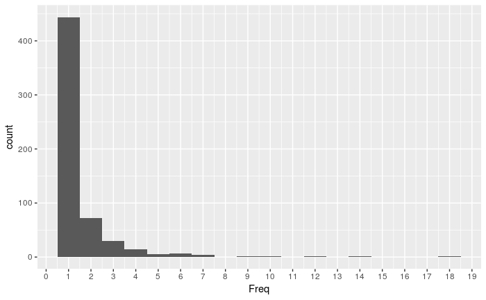

We can definately observe that the majority of artists have only one track saved. But it made me wonder how high this ratio is.

| Freq | x |
| --- | --- |
| 1 | 0.76027397 |
| 2 | 0.24657534 |
| 3 | 0.15410959 |
| 4 | 0.09589041 |
| 5 | 0.05136986 |
| 6 | 0.07191781 |
| 7 | 0.04794521 |
| 9 | 0.01541096 |
| 10 | 0.01712329 |
| 12 | 0.04109589 |

[output cut: 2 more lines]

## Time dimension

It’s important to know the span of the data. Which was the first song and which was the latest?

Firts we need to convert from `Factor` to a date format.

```
[1] 3.232877
```

That’s approximately 3 years and 2 months worth of music saving.

## Track Features

This part really interests me and, since there are a fair amount of features, I’m condensing those analysis. I’m focusing on features that might hold interesting information: Danceability, energy, instrumentalness, speechiness, popularity and acousticness. These information can tell a lot of a given track, let alone a library of them.

### Summary

```
  danceability        energy        speechiness      instrumentalness   popularity     acousticness
 Min.   :0.1030   Min.   :0.0332   Min.   :0.02500   Min.   :0.0000   Min.   : 0.00   Min.   :0.0000055
 1st Qu.:0.6780   1st Qu.:0.5200   1st Qu.:0.04400   1st Qu.:0.2465   1st Qu.: 6.00   1st Qu.:0.0017400
 Median :0.7570   Median :0.6620   Median :0.05450   Median :0.8300   Median :19.00   Median :0.0159000
 Mean   :0.7263   Mean   :0.6441   Mean   :0.08588   Mean   :0.6290   Mean   :21.13   Mean   :0.1360420
 3rd Qu.:0.8020   3rd Qu.:0.7850   3rd Qu.:0.07845   3rd Qu.:0.8950   3rd Qu.:33.00   3rd Qu.:0.1455000
 Max.   :0.9830   Max.   :0.9910   Max.   :0.68100   Max.   :0.9720   Max.   :78.00   Max.   :0.9700000
```

#### Danceability

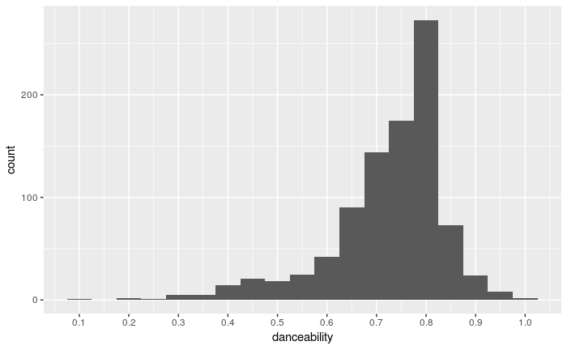

#### Energy

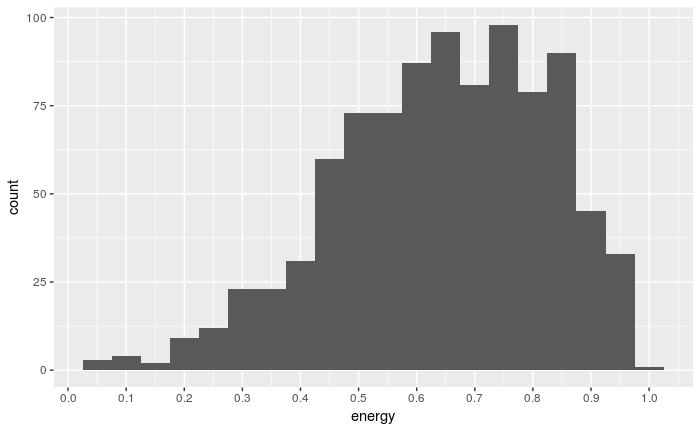

#### Speechiness

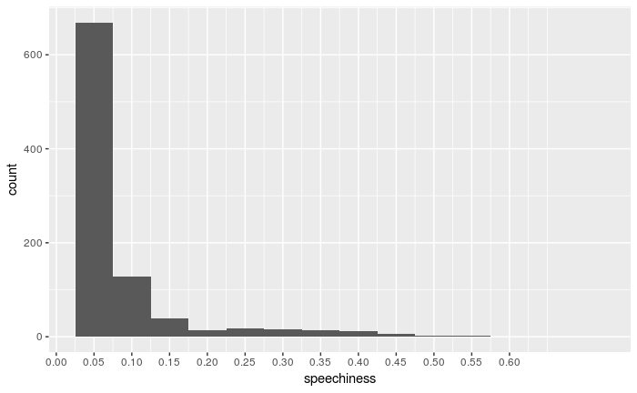

#### Instrumentalness

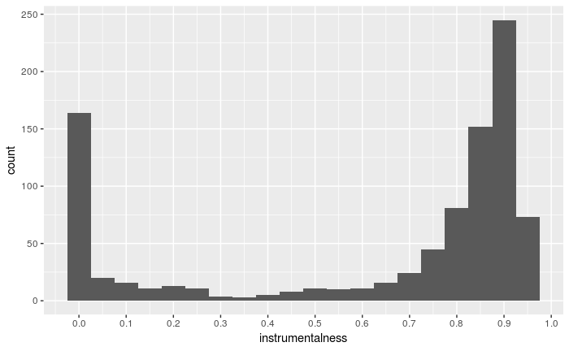

#### Acousticness

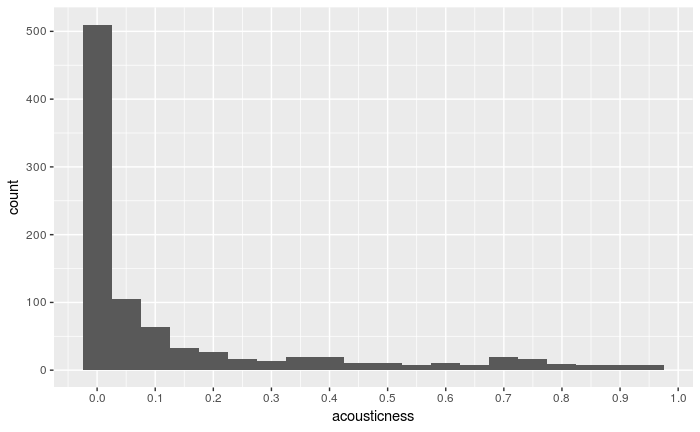

#### Popularity

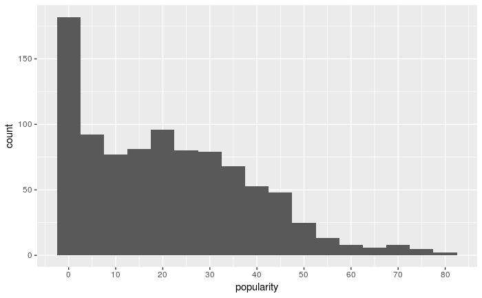

These plots are enlightening. They clearly show a pattern here: I tend to like tracks that are danceable, energetic, mostly instrumental with very few vocals. This came somewhat expectedly, due to my taste in electronic music. But I also tend to listen to rap and hip hop, that have vocals. It’s not reflecting on my saved tracks. Perhaps I don’t like it that much?

## Keys

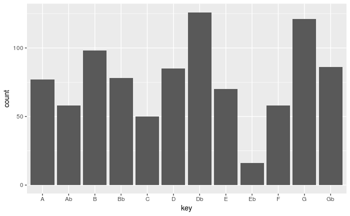

### What is the structure of your dataset?

The chosen dataset is relatively small one, with 923 records but also relatively dense: 23 features. Each row consist of an event of track saving on my Spotify library. Most of the features have values ranging from 0 to 1. It’s the magnitude of a given feature e.g. instrumentalness indicates, from 0 to 1, on how instrumental a track is.

### What is/are the main feature(s) of interest in your dataset?

Features I’m most interested in have had their distributions plotted above. They are: Danceability, energy, instrumentalness, speechiness, popularity and acousticness. Even though there are many features, a few do might hold some information on how my taste have evolved, which are the ones I selected.

### Did you perform any operations on the data to tidy, adjust, or change the form of the data? If so, why did you do this?

For this first brief analysis I only had to take out a single missing value. Besides that, variables had been analyzed alone, so no feature engineering was done.

# Bivariate Plots Section

Now we’re ready to explore how the features relates with themselves. As of now, we’ll limit to pair – bivariate – analysis. The first thing that come to mind is to explore the time dimension of this dataset.

#### Time added

Now we can analyze grouping by date:

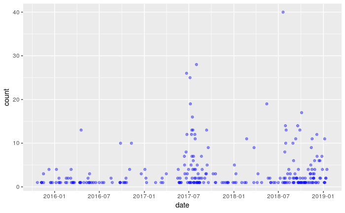

It clearly has an increase from the middle of 2017 on. If we grouped this data monthly we’d see a trend maybe?

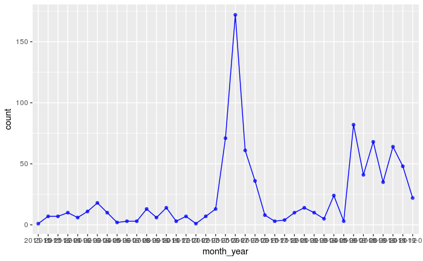

|  | month_year | count |
| --- | --- | --- |
| 21 | 2017-07 | 172 |
| 33 | 2018-07 | 82 |
| 20 | 2017-06 | 71 |
| 35 | 2018-09 | 68 |
| 37 | 2018-11 | 64 |
| 22 | 2017-08 | 61 |
| 38 | 2018-12 | 48 |
| 34 | 2018-08 | 41 |
| 23 | 2017-09 | 36 |
| 36 | 2018-10 | 35 |

[output cut: 29 more lines]

I was almost right. July 2017 was the month I added 172 songs. That’s 18% of the entire dataset volume. You can see that the second highest is July 2018. Maybe there’s a pattern there?

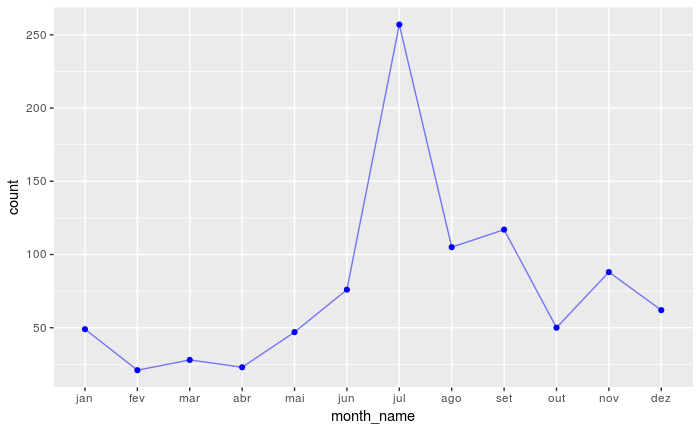

The graph confirms our assumption: fore some reason songs are added more on the second semester than the first one.

### Danceability x Popularity

How much danceability correlates with popularity?

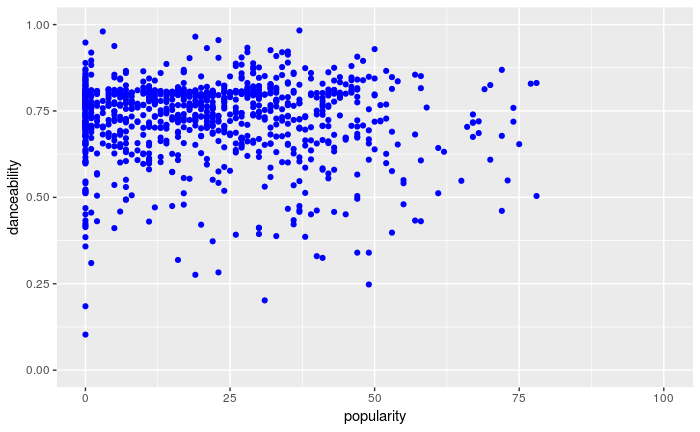

Well it seems that not so much. By analyzing the graph and density points we can tell that most songs that are danceable do not rank high in popularity.

### Tempo x Danceability

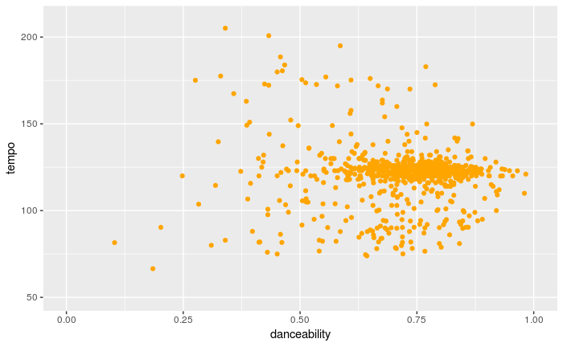

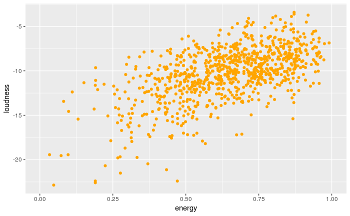

There seems to be a correlation between a track’s energy and how loud it is. A little (too much) expected. But how correlated are they?

```
    Pearson's product-moment correlation

data:  energy and loudness
t = 22.152, df = 921, p-value < 0.00000000000000022
alternative hypothesis: true correlation is not equal to 0
95 percent confidence interval:
 0.5458111 0.6301299
sample estimates:
      cor
0.5895744
```

## Key vs Instrumentalness

[output not shown]

[output cut: 913 more lines]

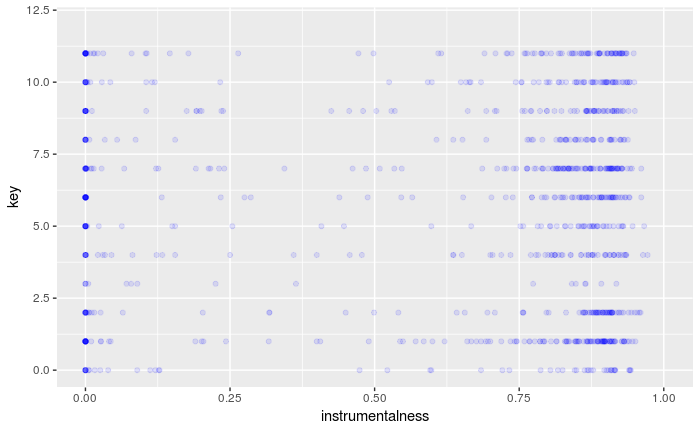

# Multivariate Analysis

## What influences danceability?

I suspect that a few features have latent relationships with danceability. And since understanding what lies behind this feature is of much interest, let’s plot it:

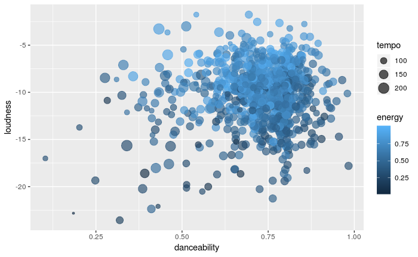

## Track Profile

When I noticed that a lot of features have the same range ([0.0, 1.0]). So what does an average track sampled from my library would look like?

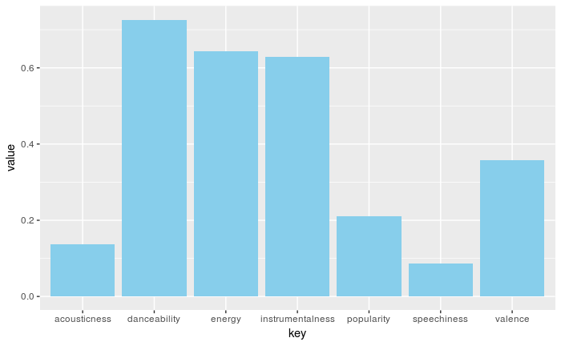

And it’s confirmed: I like musics that are danceable, energetic and with lots of instrumentals. Also, these tracks tend to be low on acoustic and speechiness and not popular.

## Time lapse

If we were to plot, aggregating monthly, the average on each feature, how would these features place evolve (if they evolve at all) through time?

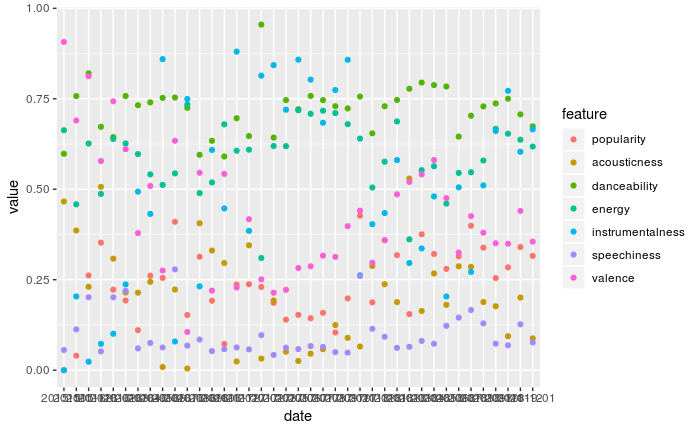

Well, that before metioned evolution don’t exist. Those time series are rather stochastic. But when it comes to danceability and energy, it stands above a baseline. Meaning that throughout this time my taste for energetic and danceable tunes remained rather the same. It’s interesting also to note how my listening to acoustic songs vary over time.

## Heatmaps

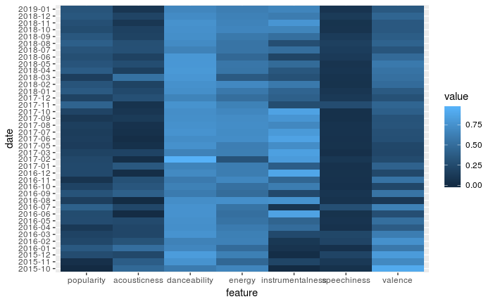

That scatterplot above was more confusing than elusive. Now this heatmap is great at displaying patterns. It is crystal clear on how each feature, on average, changed month to month. The assumptions behind danceability, energy and acousticness are clearly verifiable.

# Final Plots and Summary

# Reflection

I wish I was more proficient on R language in order to write and create more professionally. But I value these kinds of tasks that take me out of my comfort zone to learn new things, which was the idea of this whole course. I’ve had a few issues on data transformation and overall language syntax and writing styles but I think I managed to get it done.

I also am aware that many more analysis could have been done. There was the genre feature that I missed. I could have scraped to get it as well but time was a constraint here.